# Experts tell White House coronavirus can spread through talking or even just breathing

While it was previously thought that coronavirus was spread through the sneezes/coughs of infected individuals, a scientific panel at **the White House** revealed that [the virus can also be spread by simply talking or breathing](https://www.cnn.com/2020/04/02/health/aerosol-coronavirus-spread-white-house-letter/index.html). In more technical terms, research results around the world have found the transmission of coronavirus to be consistent with aerosolization of the virus from normal breathing. Due to this recent discovery, *Dr. Anthony Fauci*, a member of **the White House’s coronavisus task force** revealed that recommending the general use of masks by all individuals is under active discussion by the task force. *Dr. Harvey Fineberg*, chairman of a committee with the **National Academy of Sciences**, further spoke on the matter by declaring his own precautionary practices, stating that:

> “I’m not going to wear a surgical mask, because clinicians need those, but I have a nice western-style bandana I might wear. Or I have a balaclava. I have some pretty nice options.”"

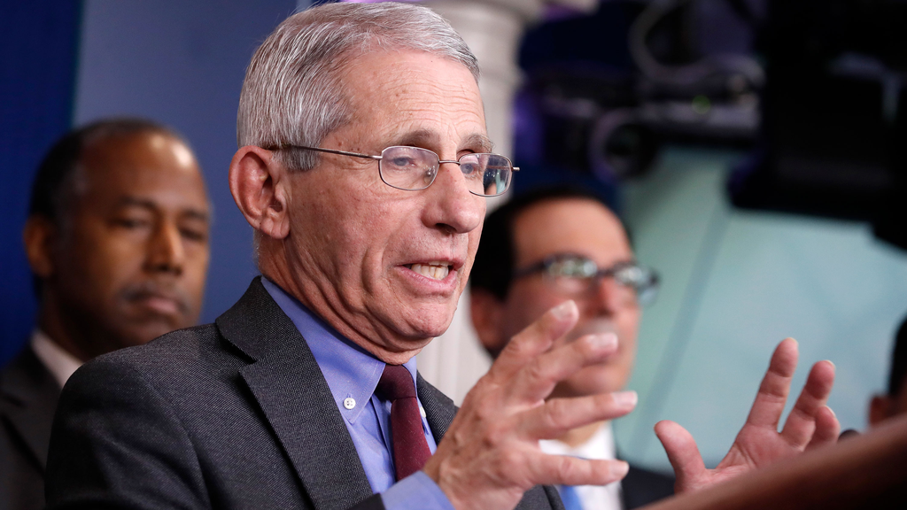

Dr. Anthony Fauci, director of the National Institute of Allergy and Infectious Diseases, speaks during a White House briefing on coronavirus in the Brady Room at the White House

Important points to consider:

- Information from the CDC prior to this discovery simply stated that [the virus spread person to person when people are within about 6 feet from each other](https://www.cdc.gov/coronavirus/2019-ncov/prevent-getting-sick/how-covid-spreads.html)
- Dr. Fineberg [developed on this](https://thehill.com/changing-america/well-being/prevention-cures/490831-coronavirus-could-spread-through-talking-and) stating that it is even possible for aerosilized droplets containing the virus to be suspended in the air when doctors and nurses remove gear, when floors are cleaned, or when staff move around, potentially being to infect someone who walks by later.
- All things considered, coronavirus is still [not as infection as measles or small pox](https://massivesci.com/articles/coronavirus-covid19-sars-mers-quarantine-social-distancing/)